# 3.Naive Bayes

Affluence Tan

January 3, 2017

## 简单理解朴素贝叶斯

朴素贝叶斯分类来自于贝叶斯定理的简单应用。

### 公式定义

假设某样本有n项特征（Feature），分别为$F_1$、$F_2$、…、$F_n$。现有m个类别（Category），分别为$C_1$、$C_2$、…、$C_m$。贝叶斯分类器就是计算出概率最大的那个分类，也就是求下面这个算式的最大值：

$P(C|F_1F_2...F_n)=\frac{P(F_1F_2...F_n|C)P(C)}{P(F_1F_2...F_n)}$

由于$P(F_1F_2...F_n)$对每一个分类都是相同的，可以省。所以就变成了求下面公式的最大值：

$P(F_1F_2...F_n|C)P(C)$

### 什么是朴素

朴素是假设所有特征都彼此独立，这个假设也是其缺点。因此公式变成了：

$P(F_1F_2...F_n|C)P(C)=P(F_1|C)P(F_2|C)...P(F_n|C)P(C)$

### 拉普拉斯估计

当其中一个特征的似然概率为0时，由于上面公式连乘的原因，后验概率一定为0。这个在通常情况下将没有意义。这时候，可以使用拉普拉斯估计解决，在频率表的每个计数上面加一个比较小的数，通常为1。

### 朴素贝叶斯的变量

运用朴素贝叶斯分类，变量应该都是离散型变量，如果是连续型变量，要先分段。太少的分段会导致信息量减少，重要趋势被掩盖，太多分段导致频率的计数值太小。

## R实战

### 获取数据集

```r
library(readr)
adult <- read_csv("adult.csv",na="?")
adult$income = as.factor(adult$income)
str(adult)
```

```
## Classes 'tbl_df', 'tbl' and 'data.frame':    32561 obs. of  15 variables:
##  $ age           : int  39 50 38 53 28 37 49 52 31 42 ...
##  $ workclass     : chr  "State-gov" "Self-emp-not-inc" "Private" "Private" ...
##  $ fnlwgt        : int  77516 83311 215646 234721 338409 284582 160187 209642 45781 159449 ...
##  $ education     : chr  "Bachelors" "Bachelors" "HS-grad" "11th" ...
##  $ education_num : int  13 13 9 7 13 14 5 9 14 13 ...
##  $ marital_status: chr  "Never-married" "Married-civ-spouse" "Divorced" "Married-civ-spouse" ...
##  $ occupation    : chr  "Adm-clerical" "Exec-managerial" "Handlers-cleaners" "Handlers-cleaners" ...
##  $ relationship  : chr  "Not-in-family" "Husband" "Not-in-family" "Husband" ...
##  $ race          : chr  "White" "White" "White" "Black" ...
##  $ sex           : chr  "Male" "Male" "Male" "Male" ...
##  $ capital_gain  : int  2174 0 0 0 0 0 0 0 14084 5178 ...
##  $ capital_loss  : int  0 0 0 0 0 0 0 0 0 0 ...
##  $ hours_per_week: int  40 13 40 40 40 40 16 45 50 40 ...
##  $ native_country: chr  "United-States" "United-States" "United-States" "United-States" ...
##  $ income        : Factor w/ 2 levels "<=50K",">50K": 1 1 1 1 1 1 1 2 2 2 ...
```

这个是美国成人的人口统计资料，要预测的是income这个变量。

### 探索和准备数据集

```r
library(Hmisc)
library(ggplot2)
library(dplyr)
```

```r
describe(adult)
```

```
## adult
##
##  15  Variables      32561  Observations
## ---------------------------------------------------------------------------
## age
##       n missing  unique    Mean     .05     .10     .25     .50     .75
##   32561       0      73   38.58      19      22      28      37      48
##     .90     .95
##      58      63
##
## lowest : 17 18 19 20 21, highest: 85 86 87 88 90
## ---------------------------------------------------------------------------
## workclass
##       n missing  unique
##   30725    1836       8
##
## Federal-gov (960, 3%), Local-gov (2093, 7%)
## Never-worked (7, 0%), Private (22696, 74%)
## Self-emp-inc (1116, 4%)
## Self-emp-not-inc (2541, 8%)
## State-gov (1298, 4%), Without-pay (14, 0%)
## ---------------------------------------------------------------------------
## fnlwgt
##       n missing  unique    Mean     .05     .10     .25     .50     .75
##   32561       0   21648  189778   39460   65716  117827  178356  237051
##     .90     .95
##  329054  379682
##
## lowest :   12285   13769   14878   18827   19214
## highest: 1226583 1268339 1366120 1455435 1484705
## ---------------------------------------------------------------------------
## education
##       n missing  unique
##   32561       0      16
##
##           10th 11th 12th 1st-4th 5th-6th 7th-8th 9th Assoc-acdm Assoc-voc
## Frequency  933 1175  433     168     333     646 514       1067      1382
## %            3    4    1       1       1       2   2          3         4
##           Bachelors Doctorate HS-grad Masters Preschool Prof-school
## Frequency      5355       413   10501    1723        51         576
```

[output cut: 89 more lines]

```
## lowest :  1  2  3  4  5, highest: 95 96 97 98 99
## ---------------------------------------------------------------------------
## native_country
##       n missing  unique
##   31978     583      41
##
## lowest : Cambodia        Canada          China           Columbia        Cuba
## highest: Thailand        Trinadad&Tobago United-States   Vietnam         Yugoslavia
## ---------------------------------------------------------------------------
## income
##       n missing  unique
##   32561       0       2
##
## <=50K (24720, 76%), >50K (7841, 24%)
## ---------------------------------------------------------------------------
```

从上面的结果可以看到，数据中有一些缺失值。但是据说朴素贝叶斯对缺失值不敏感。所以先不管。 最后一个变量是预测变量，分别是大于50K和小于等于50K。并且给出了比例24%和76%。下面切分数据集。

```r
# create training and test data
adult_train <- adult[1:21000, ]
adult_test <- adult[21001:32561, ]
```

### 基于数据集训练模型

```r
# load the "e1701" library
library(e1071)
adult_classifier <- naiveBayes(income ~ ., data = adult_train,laplace = 1)
adult_predictions <- predict(adult_classifier, adult_test[,-15])
```

查阅了一下e1071的帮助文档，naiveBayes的data变量接受数值型变量和分类型变量。前面提到，朴素贝叶斯只能用于分类型变量，估计函数自动进行了转化。

### 评估模型性能

```r
# load the "gmodels" library
library(gmodels)
library(ROCR)
# Create the cross tabulation of predicted vs. actual
CrossTable(x = adult_test$income, y = adult_predictions,
           prop.chisq=FALSE)
```

```
##
##
##    Cell Contents
## |-------------------------|
## |                       N |
## |           N / Row Total |
## |           N / Col Total |
## |         N / Table Total |
## |-------------------------|
##
##
## Total Observations in Table:  11561
##
##
##                   | adult_predictions
## adult_test$income |     <=50K |      >50K | Row Total |
## ------------------|-----------|-----------|-----------|
##             <=50K |      8337 |       387 |      8724 |
##                   |     0.956 |     0.044 |     0.755 |
##                   |     0.804 |     0.323 |           |
##                   |     0.721 |     0.033 |           |
## ------------------|-----------|-----------|-----------|
##              >50K |      2027 |       810 |      2837 |
##                   |     0.714 |     0.286 |     0.245 |
##                   |     0.196 |     0.677 |           |
##                   |     0.175 |     0.070 |           |
## ------------------|-----------|-----------|-----------|
##      Column Total |     10364 |      1197 |     11561 |
##                   |     0.896 |     0.104 |           |
## ------------------|-----------|-----------|-----------|
##
##
```

```r
adult_predictions_prob <- predict(adult_classifier, adult_test[,-15],type = "raw")
pred <- prediction(predictions = adult_predictions_prob[,2] ,labels = adult_test$income)
perf.auc <- performance(pred,measure = "auc")
str(perf.auc)
```

```
## Formal class 'performance' [package "ROCR"] with 6 slots
##   ..@ x.name      : chr "None"
##   ..@ y.name      : chr "Area under the ROC curve"
##   ..@ alpha.name  : chr "none"
##   ..@ x.values    : list()
##   ..@ y.values    :List of 1
##   .. ..$ : num 0.814
##   ..@ alpha.values: list()
```

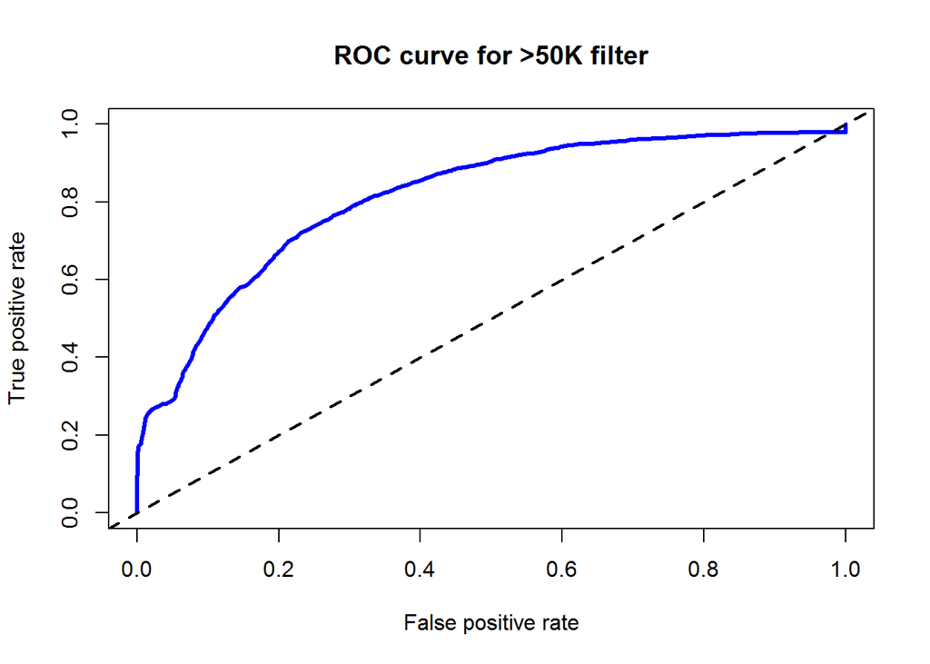

```r
perf <- performance(pred,measure = "tpr", x.measure = "fpr")
plot(perf, main = "ROC curve for >50K filter", col ="blue",lwd = 3)
abline(a=0,b=1,lwd =2,lty =2)
```

可以看到，模型的准确度为0.721+0.070 = 0.791，也就是说79.1是预测正确了，乍一看不错，但是我们知道，即便没有模型，全部评判为收入不到50k,我们也可以有76%的准确度，模型的效果有限。而且在收入大于50K的人群中，只有28.6%的人被挑选出来了，模型还需要改进。

ROC曲线这里先不解释。

### 提高模型性能

之前提到，我不太清楚e1071包中的naiveBayes是如何给连续变量转化为类别型的。现在我自己来做这件事，看看能不能提高模型的预测。

先画图考察一下连续变量。

```
## stat_bin: binwidth defaulted to range/30. Use 'binwidth = x' to adjust this.
## stat_bin: binwidth defaulted to range/30. Use 'binwidth = x' to adjust this.
```

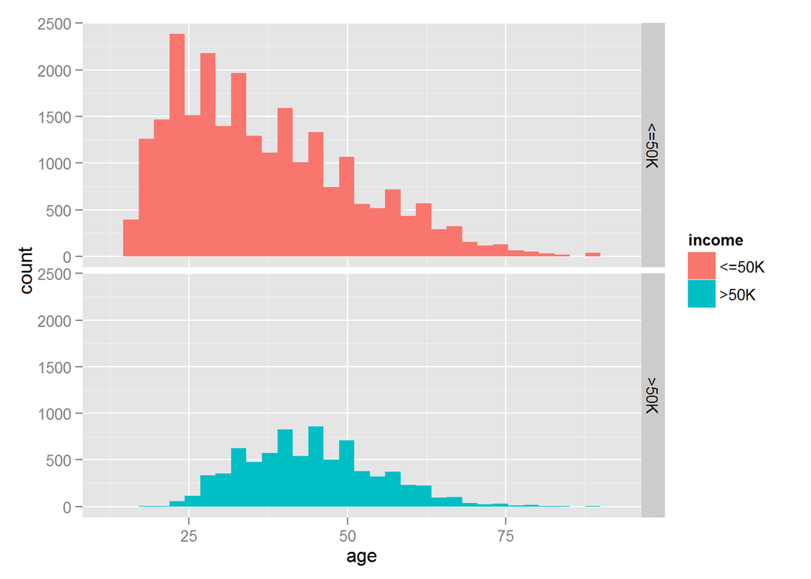

```r
# plot histogram
varname <- c("age","fnlwgt","education_num","capital_gain","capital_loss","hours_per_week")
adult_continuous <- adult[varname]
adult_continuous$income = adult$income

g_age <- ggplot(data = adult_continuous,aes(x=age,fill=income))
g_age + geom_bar()+facet_grid(income ~ .)
```

```
## stat_bin: binwidth defaulted to range/30. Use 'binwidth = x' to adjust this.
## stat_bin: binwidth defaulted to range/30. Use 'binwidth = x' to adjust this.
```

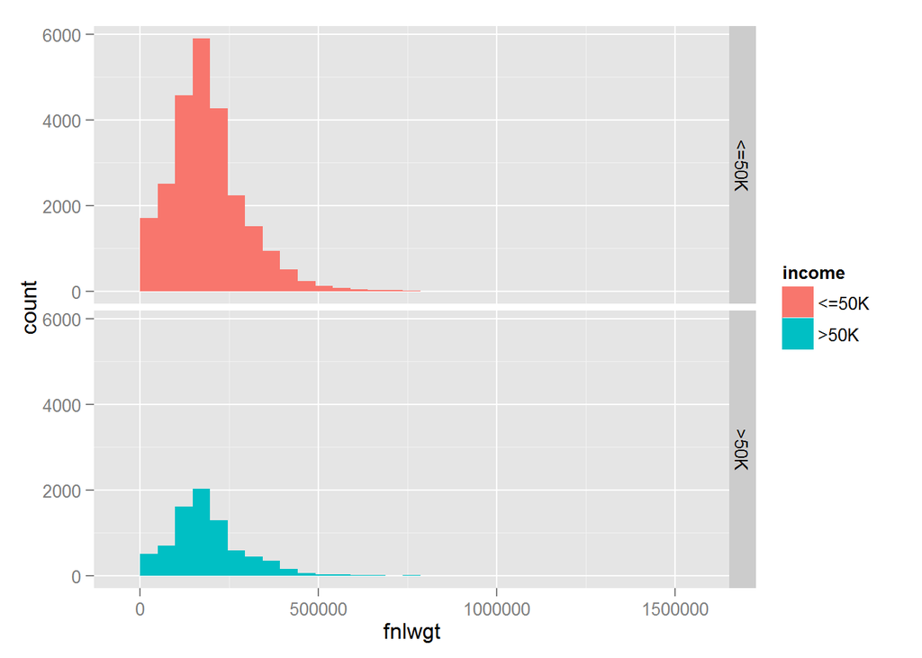

```r
g_fnlwgt <- ggplot(data = adult_continuous,aes(x=fnlwgt,fill=income))
g_fnlwgt + geom_bar()+facet_grid(income ~ .)
```

```
## stat_bin: binwidth defaulted to range/30. Use 'binwidth = x' to adjust this.
## stat_bin: binwidth defaulted to range/30. Use 'binwidth = x' to adjust this.
```

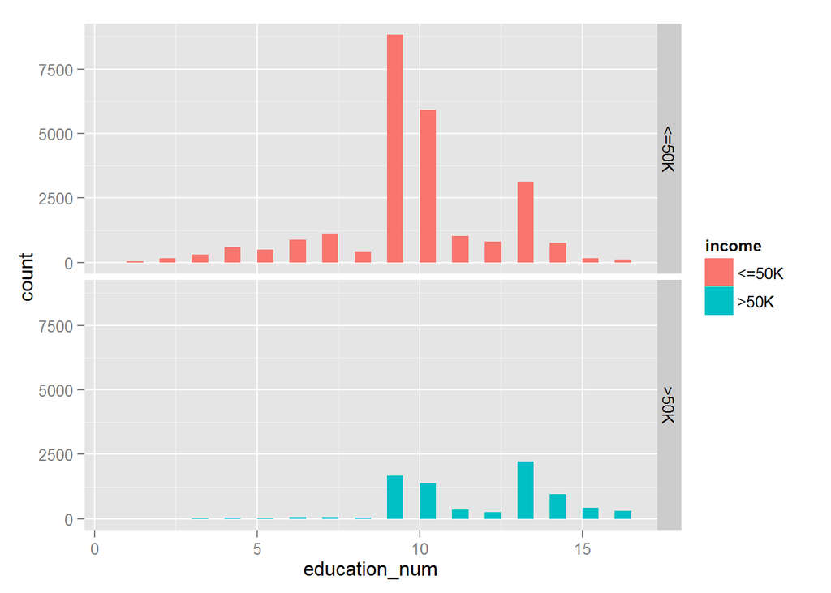

```r
g_education <- ggplot(data = adult_continuous,aes(x=education_num,fill=income))
g_education + geom_bar()+facet_grid(income ~ .)
```

```
## stat_bin: binwidth defaulted to range/30. Use 'binwidth = x' to adjust this.
## stat_bin: binwidth defaulted to range/30. Use 'binwidth = x' to adjust this.
```

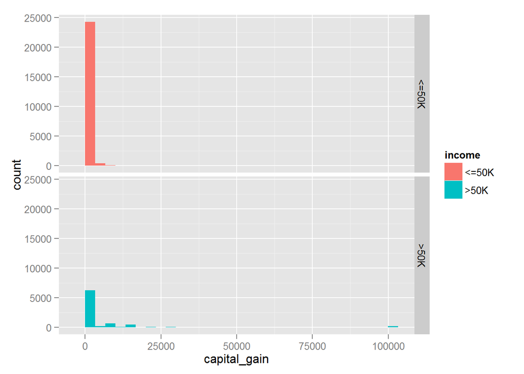

```r
g_gain <- ggplot(data = adult_continuous,aes(x=capital_gain,fill=income))
g_gain + geom_bar()+facet_grid(income ~ .)
```

```
## stat_bin: binwidth defaulted to range/30. Use 'binwidth = x' to adjust this.
## stat_bin: binwidth defaulted to range/30. Use 'binwidth = x' to adjust this.
```

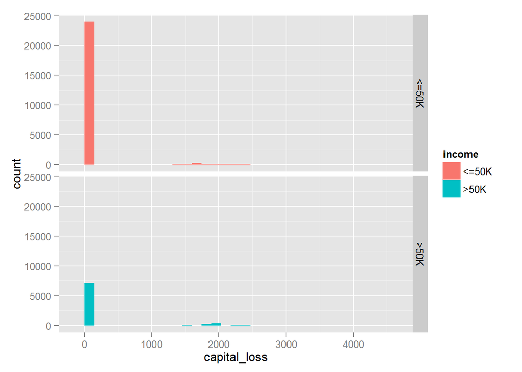

```r
g_loss <- ggplot(data = adult_continuous,aes(x=capital_loss,fill=income))
g_loss + geom_bar()+facet_grid(income ~ .)
```

```
## stat_bin: binwidth defaulted to range/30. Use 'binwidth = x' to adjust this.
## stat_bin: binwidth defaulted to range/30. Use 'binwidth = x' to adjust this.
```

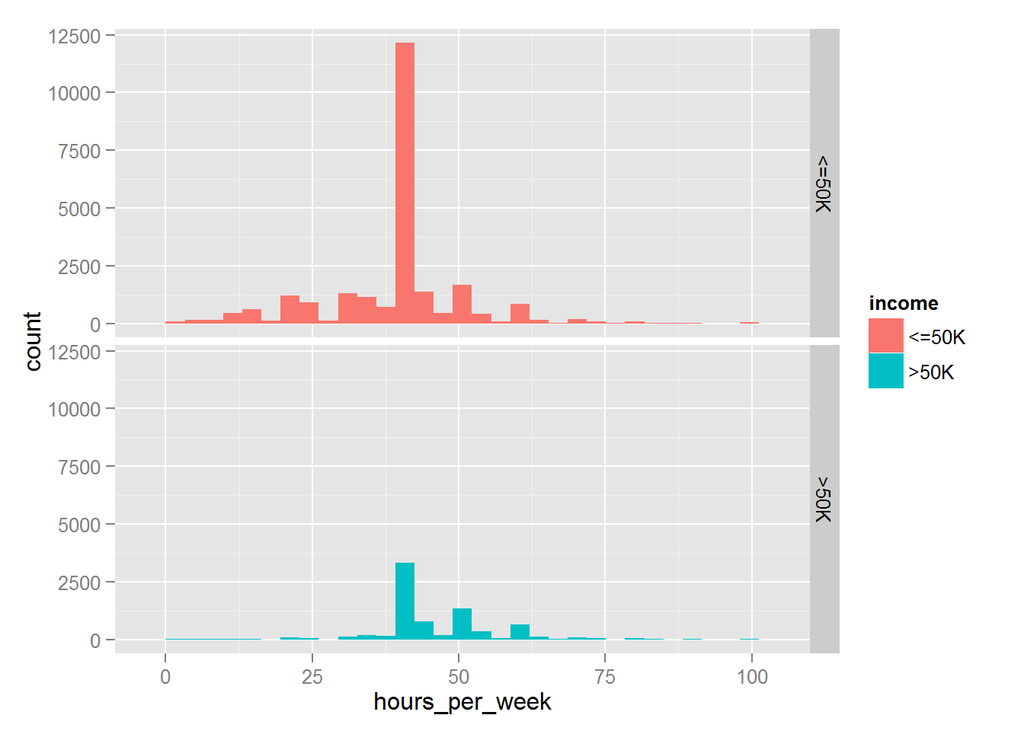

```r
g_hours <- ggplot(data = adult_continuous,aes(x=hours_per_week,fill=income))
g_hours + geom_bar()+facet_grid(income ~ .)
```

可以看到fnlwgt变量没有什么影响，所以就不做离散化处理了。capital_gain和capital_loss 有太多0，先把0去掉再画一下直方图。

```
## stat_bin: binwidth defaulted to range/30. Use 'binwidth = x' to adjust this.
## stat_bin: binwidth defaulted to range/30. Use 'binwidth = x' to adjust this.
```

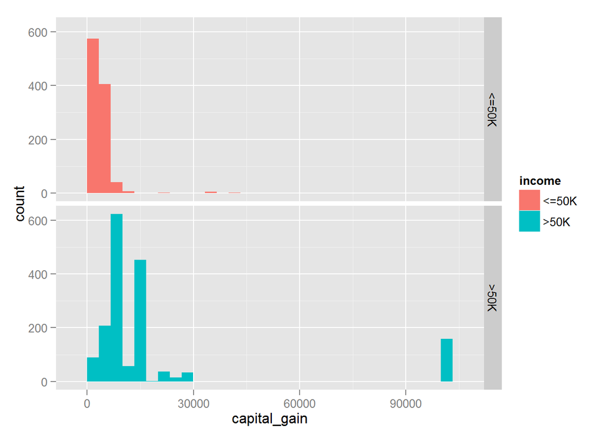

```r
capital_gain_remove0 = filter(.data = adult,capital_gain > 0)
g_gain <- ggplot(data = capital_gain_remove0,aes(x=capital_gain,fill=income))
g_gain + geom_bar() + facet_grid(income ~ .)
```

```
## stat_bin: binwidth defaulted to range/30. Use 'binwidth = x' to adjust this.
## stat_bin: binwidth defaulted to range/30. Use 'binwidth = x' to adjust this.
```

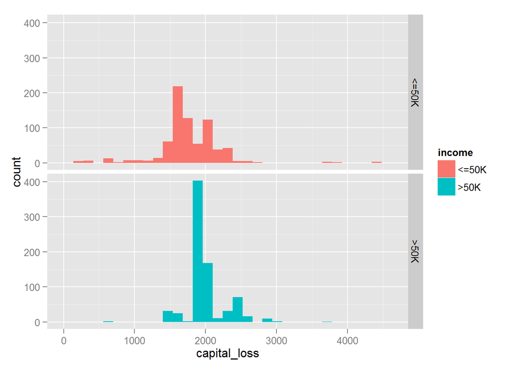

```r
capital_loss_remove0 = filter(.data = adult,capital_loss > 0)
g_loss <- ggplot(data = capital_loss_remove0,aes(x=capital_loss,fill=income))
g_loss + geom_bar() + facet_grid(income ~ .)
```

现在做类别化处理

```r
adult_str <- adult

adult_str$age <- as.factor(floor(adult$age / 10))

adult_str$education_num <- as.factor(adult$education_num)
# capital_gain discretization according to histogram
capital_gain <- adult$capital_gain
capital_gain <- ifelse(capital_gain <6000 & capital_gain >0, 1 ,capital_gain)
capital_gain <- ifelse(capital_gain <30000 & capital_gain >=6000, 2 ,capital_gain)
capital_gain <- ifelse(capital_gain <60000 & capital_gain >=30000, 3 ,capital_gain)
capital_gain <- ifelse(capital_gain >=60000, 4 ,capital_gain)
adult_str$capital_gain <- as.factor(capital_gain)
# capital_loss discretization according to histogram
capital_loss <- adult$capital_loss
capital_loss <- ifelse(capital_loss <1400 & capital_loss >0, 1 ,capital_loss)
capital_loss <- ifelse(capital_loss <1700 & capital_loss >=1400, 2 ,capital_loss)
capital_loss <- ifelse(capital_loss <2200 & capital_loss >=1700, 3 ,capital_loss)
capital_loss <- ifelse(capital_loss <3000 & capital_loss >=2200, 4 ,capital_loss)
capital_loss <- ifelse(capital_loss >=3000, 5 ,capital_loss)
adult_str$capital_loss <- as.factor(capital_loss)

adult_str$hours_per_week <- as.factor(floor(adult$hours_per_week / 10))
```

在capital_gain和capital_loss这两个变量上面我多花了点心思，下面重新拟合模型。

```r
# create training and test data
adult_train <- adult_str[1:21000, ]
adult_test <- adult_str[21001:32561, ]
# build model
adult_classifier <- naiveBayes(income ~ ., data = adult_train,laplace = 1)
adult_predictions <- predict(adult_classifier, adult_test[,-15])
```

```r
# Create the cross tabulation of predicted vs. actual
CrossTable(x = adult_test$income, y = adult_predictions,
           prop.chisq=FALSE)
```

```
##
##
##    Cell Contents
## |-------------------------|
## |                       N |
## |           N / Row Total |
## |           N / Col Total |
## |         N / Table Total |
## |-------------------------|
##
##
## Total Observations in Table:  11561
##
##
##                   | adult_predictions
## adult_test$income |     <=50K |      >50K | Row Total |
## ------------------|-----------|-----------|-----------|
##             <=50K |      8127 |       597 |      8724 |
##                   |     0.932 |     0.068 |     0.755 |
##                   |     0.851 |     0.297 |           |
##                   |     0.703 |     0.052 |           |
## ------------------|-----------|-----------|-----------|
##              >50K |      1424 |      1413 |      2837 |
##                   |     0.502 |     0.498 |     0.245 |
##                   |     0.149 |     0.703 |           |
##                   |     0.123 |     0.122 |           |
## ------------------|-----------|-----------|-----------|
##      Column Total |      9551 |      2010 |     11561 |
##                   |     0.826 |     0.174 |           |
## ------------------|-----------|-----------|-----------|
##
##
```

可以看到，模型的预测准确率有了提升(0.703+0.122=0.825),更为关键的是对收入大于50K的人群的预测有提升。精确度和回溯率分别为0.703和0.498。

## 小结

上面的模型改进也可以看到，朴素贝叶斯模型比较适合于类别变量，不同的连续变量类别化的方法会对模型精度产生比较大的影响。

朴素贝叶斯更加典型的应用场景是在过滤垃圾邮件分类的方面。